# Variance Structures in Mixed Models

Michael Liou

2022-06-28

> The following document is a work in progress!

# Introduction

Using random effects into the modeling equation gives us an opportunity to account for correlations among observations in a structured manner. Having a lot of flexibility in modeling a covariance structure is generally a pretty computationally difficult problem, but modern software have made this problem rather manageable. There are many numerical methods of solving the same equations, and thus a wide array of software to consider. Given the numerical complexity of the problem, the software will often times give different estimates and standard errors.

The example that we use throughout this section is a [multi-environment potato RCBD](https://rdrr.io/cran/sommer/man/DT_example.html) (`DT_example` from the `sommer` package). The covariates in the dataset are:

- `Name` - the genotype of potato plant
- `Env` - location/year combination.
- `Block` - coded uniquely across the environments
- `Yield` - a response, the number of potatoes from the plant
- `Weight` - another response, weight of the potatoes, to illustrate multiple trait experiments

```r
data(DT_example) # library(sommer)
```

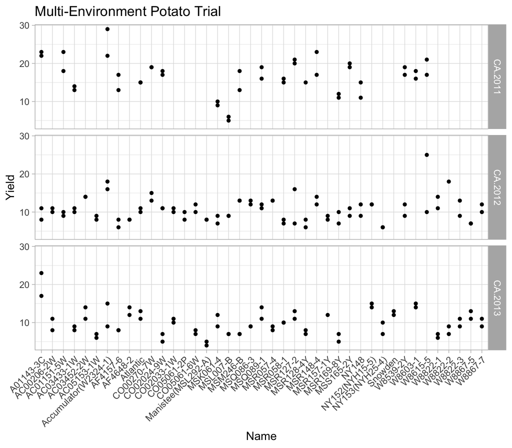

```r
DT_example %>% ggplot(aes(Name, Yield)) +
  geom_point() +
  facet_grid(Env~.) +
  theme_light(base_size = 13) +
  theme(axis.text.x = element_text(angle = 45, vjust = 1, hjust = 1)) +
  labs(title = "Multi-Environment Potato Trial")
```

# Theory

**Under construction**

# Ecosystem Overview

The R packages that can do forms of variance covariance structures (not an exhaustive list):

[output not shown]

<sup>1</sup> ?? means I haven’t tried the software  
<sup>2</sup> AI = Average Information, AD = Automatic Differentiation, NR = Newton Rapheson, EMMA = Efficient Mixed Model Association, EM = Expectation-Maximization, MOM = Method of Moments;

1. nlme
2. SAS (proc MIXED)
3. glmmTMB
4. sommer

`nlme` will offer many options of variance structure with similar performance if you need more flexibility, but does not deal with crossed random effects. SAS has a very intuitive interface for specifying the “G”-side and “R”-side and will likely be able to handle your use case. glmmTMB also has a very intuitive syntax, mostly following lme4 syntax, but currently the “R”-side modeling is kind of hackish and a workaround (sets the residual error to something very small). sommer I think is the newest package, and thus the components of design are still settling. It is by far the most flexible for variance structure designs, and targeted specifically to those working in multi-environment trails but I think the syntax does take some getting used to.

- sommer - takes an AS-REML approach to fitting the variance components.
- glmmTMB ([R Package](https://cran.r-project.org/web/packages/glmmTMB/index.html)) ([Paper](https://journal.r-project.org/archive/2017/RJ-2017-066/RJ-2017-066.pdf)) - is primarily a glmm package that uses lme4 based formula syntax. It uses the r package `TMB` in the background, which is MLE based and uses Laplace approximations for integrating out random effects.
- SAS ([Docs](https://documentation.sas.com/doc/en/statcdc/14.2/statug/statug_mixed_details01.htm)) ([paper](https://www.researchgate.net/publication/242913395_Computing_Gaussian_Likelihoods_and_Their_Derivatives_for_General_Linear_Mixed_Models)) - uses a sweep method on the REML and ML profiled likelihood. There’s good discussion of the methods in their documentation.
- afex - reformulates the formula statement and uses lme4 in the background
- MCMCglmm - takes a bayesian simulation approach to mixed modeling
- INLA - Integrated Nested Laplacian Approximation

## nlme

nlme is a rather stable package with a lot of facilities to account for many different variance structures on both the “G”-side and the “R”-side.

See `?pdClasses` and `?varClasses` for functional variance modeling.

## sommer

You can probably think of sommer as the free version of AS-REML. It particularly specializes in multienvironment, and heterogenous variance structures.

The variance component specification is a little cryptic, but based mostly on hadamard matrix multiplication.

- `mmer`
  - `vsr` = “Variance Structure for Random effects”, use this to build the variance, outer function
    - `dsr` = diagonal covariance structure
    - `usr` = unstructure covraince structure
- `mmec` - the main “average information” algorithm for solving
  - `vsc` = “variance structure for coefficients”, `random=~vsc(e, f, h, g)` means var(g) = G.e @ G.f @ G.h @ I.g
    - `isc` = identity covariance structure

The numbering in the matrix means it’s a constraint

0. not to be estimated
1. estimated and constrained to be positive (i.e. variance component)
2. estimated and unconstrained (i.e., normally a covariance)
3. not estimated but fixed (provided by `Gti` arg)

```r
x <- as.factor(c(1:5,2:6,1:5))
usr(x) # list(vector, vcov structure)
```

```
## [[1]]
##    1 2 3 4 5 6
## 1  1 0 0 0 0 0
## 2  0 1 0 0 0 0
## 3  0 0 1 0 0 0
## 4  0 0 0 1 0 0
## 5  0 0 0 0 1 0
## 6  0 1 0 0 0 0
## 7  0 0 1 0 0 0
## 8  0 0 0 1 0 0
## 9  0 0 0 0 1 0
## 10 0 0 0 0 0 1
## 11 1 0 0 0 0 0
## 12 0 1 0 0 0 0
## 13 0 0 1 0 0 0
```

[output cut: 17 more lines]

```r
x <- as.factor(c(1:5,1:5,1:6))
csr(x, matrix(1, 6, 6))
```

```
## [[1]]
##    1 2 3 4 5 6
## 1  1 0 0 0 0 0
## 2  0 1 0 0 0 0
## 3  0 0 1 0 0 0
## 4  0 0 0 1 0 0
## 5  0 0 0 0 1 0
## 6  1 0 0 0 0 0
## 7  0 1 0 0 0 0
## 8  0 0 1 0 0 0
## 9  0 0 0 1 0 0
## 10 0 0 0 0 1 0
## 11 1 0 0 0 0 0
## 12 0 1 0 0 0 0
## 13 0 0 1 0 0 0
```

[output cut: 18 more lines]

```r
x <- as.factor(c(1:5,2:6,1:5))
dsr(x) # list(vector, vcov)
```

```
## [[1]]
##    1 2 3 4 5 6
## 1  1 0 0 0 0 0
## 2  0 1 0 0 0 0
## 3  0 0 1 0 0 0
## 4  0 0 0 1 0 0
## 5  0 0 0 0 1 0
## 6  0 1 0 0 0 0
## 7  0 0 1 0 0 0
## 8  0 0 0 1 0 0
## 9  0 0 0 0 1 0
## 10 0 0 0 0 0 1
## 11 1 0 0 0 0 0
## 12 0 1 0 0 0 0
## 13 0 0 1 0 0 0
```

[output cut: 17 more lines]

### Further Reading

They overview their package in [this paper](https://journals.plos.org/plosone/article?id=10.1371/journal.pone.0156744#), and implement three programs for fitting:

- Newton Rapheson Direct Inversion
- [“Average Information REML”](http://faculty.washington.edu/tathornt/BIOST551/articles_2012/AverageInformation.pdf) - original paper by same authors of the AS-REML package. A great example of this optimization step with an example is given in a book chapter by author of “sommer” package [Overview of Major Computer Packages for Genomic Prediction of Complex Traits](https://link.springer.com/protocol/10.1007/978-1-0716-2205-6_6)
- [“Efficient Mixed Model Association (EMMA)”](https://academic.oup.com/genetics/article/178/3/1709/6061473?login=false)

## SAS

- [Tips and Strategies for Mixed Modeling with SAS](https://www.lexjansen.com/mwsug/2012/SA/MWSUG-2012-SA15.pdf)

## glmmTMB

The [glmmTMB variance covariance structures vignette](https://cran.r-project.org/web/packages/glmmTMB/vignettes/covstruct.html) has a lot of information.

# Examples

## Homogenous variance

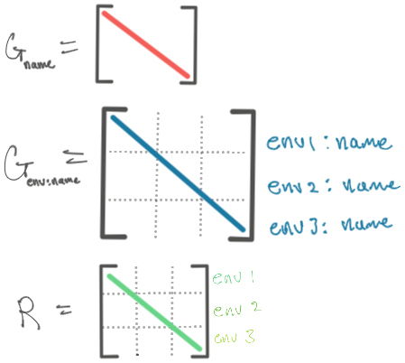

### lme4

```r
# lmer approach
mmod1 <- lmer(Yield ~ Env + (1 | Name) + (1|Env:Name), data = DT_example)
# mmod1_alt <- lmer(Yield ~ Env + (1 | Name/Env), data = DT_example) # same way of specifying model identical results

# summary(mmod1_alt)
as.data.frame(VarCorr(mmod1))$vcov
```

```
## [1] 5.173234 3.681927 4.366211
```

```r
 # Groups   Name        Std.Dev.
 # Env:Name (Intercept) 2.2745
 # Name     (Intercept) 1.9188
 # Residual             2.0895

# profiling for standard errors
pr_mmod1 <- profile(mmod1)
# xyplot (pr_mmod1 , aspect =1.3)
# splom(pr_mmod1)
# densityplot(pr_mmod1)

# taking the half the width of a .68 confidence interval as an estimate of a standard error of the estimate
confint(pr_mmod1, c(".sig01", ".sig02", ".sigma"), level = .68)^2 %>% # square for variance
  as.data.frame() %>%
  mutate(var_se_ish = (`84 %` - `16 %`) / 2)
```

```
##            16 %     84 % var_se_ish
## .sig01 3.665686 6.471304  1.4028093
## .sig02 2.248953 5.305835  1.5284410
## .sigma 3.779901 5.084092  0.6520955
```

### sommer

```r
# Univariate, homogenous variance models,
# for p > n
ans1r <- mmer(Yield ~ Env,
              random = ~ Name + Env:Name,
              rcov = ~ units, # residual structure
              data = DT_example, verbose = FALSE)
summary(ans1r)$varcomp
```

```
##                       VarComp VarCompSE   Zratio Constraint
## Name.Yield-Yield     3.681877 1.6909561 2.177394   Positive
## Env:Name.Yield-Yield 5.173062 1.4952313 3.459707   Positive
## units.Yield-Yield    4.366285 0.6470458 6.748031   Positive
```

```r
# MME-based Average information, for records > coefficients?
ans1c <- mmec(Yield~Env,
              random= ~ Name + Env:Name,
              rcov= ~ units,
              data=DT_example, verbose = FALSE)
summary(ans1c)$varcomp
```

```
##                   VarComp VarCompSE   Zratio Constraint
## Name:isc:isc     3.702831  1.698858 2.179600   Positive
## Env:Name:isc:isc 5.132119  1.875676 2.736143   Positive
## units:isc:isc    4.465685  1.611163 2.771715   Positive
```

### nlme

```r
# lme method for fitting homogenous variance model, nested
lmod1 <- lme(Yield~Env,
             random = list(Name = pdSymm(form = ~1),
                           Env = pdSymm(form = ~1)),
             method = "REML",
             data = DT_example)

summary(lmod1)
```

```
## Linear mixed-effects model fit by REML
##   Data: DT_example
##       AIC     BIC    logLik
##   948.197 967.421 -468.0985
##
## Random effects:
##  Formula: ~1 | Name
##         (Intercept)
## StdDev:     1.91884
##
##  Formula: ~1 | Env %in% Name
##         (Intercept) Residual
## StdDev:    2.274477 2.089546
##
## Fixed effects:  Yield ~ Env
##                 Value Std.Error DF   t-value p-value
## (Intercept) 16.496350 0.6855031 91 24.064589       0
## EnvCA.2012  -5.776757 0.7558206 51 -7.643027       0
## EnvCA.2013  -6.380478 0.7960544 51 -8.015128       0
##  Correlation:
##            (Intr) ECA.2012
## EnvCA.2012 -0.732
## EnvCA.2013 -0.712  0.643
##
## Standardized Within-Group Residuals:
##         Min          Q1         Med          Q3         Max
## -2.95612756 -0.46306587 -0.03282517  0.37592452  4.22246535
##
## Number of Observations: 185
## Number of Groups:
##          Name Env %in% Name
##            41            94
```

### SAS

```sas
# SAS example
proc mixed data=dt covtest;
class env name;
model yield = env;
random name name*env;
run;
```

- `covtest` - for the standard errors of covariance estimates

SAS output, homogenous variance

| Cov Parm | Estimate | Standard Error | Z-Value | Pr > Z |
| --- | --- | --- | --- | --- |
| name | 3.7861 | 1.6078 | 2.35 | 0.0093 |
| env*name | 5.1616 | 1.4675 | 3.52 | 0.0002 |
| Residual | 4.3678 | 0.6477 | 6.74 | <.0001 |

### glmmTMB

```r
tmod1 <- glmmTMB(Yield ~ Env + (1 | Name) + (1 | Env:Name),
                 REML = TRUE,
                 data = DT_example)
summary(tmod1)
```

```
##  Family: gaussian  ( identity )
## Formula:          Yield ~ Env + (1 | Name) + (1 | Env:Name)
## Data: DT_example
##
##      AIC      BIC   logLik deviance df.resid
##    948.2    967.5   -468.1    936.2      182
##
## Random effects:
##
## Conditional model:
##  Groups   Name        Variance Std.Dev.
##  Name     (Intercept) 3.682    1.919
##  Env:Name (Intercept) 5.173    2.274
##  Residual             4.366    2.090
## Number of obs: 185, groups:  Name, 41; Env:Name, 94
##
## Dispersion estimate for gaussian family (sigma^2): 4.37
##
## Conditional model:
##             Estimate Std. Error z value Pr(>|z|)
## (Intercept)  16.4964     0.6871  24.010  < 2e-16 ***
## EnvCA.2012   -5.7768     0.7581  -7.620 2.54e-14 ***
## EnvCA.2013   -6.3805     0.8008  -7.968 1.61e-15 ***
## ---
## Signif. codes:  0 '***' 0.001 '**' 0.01 '*' 0.05 '.' 0.1 ' ' 1
```

### Comparison

The results with lmer are quite close, but the effect from average information is quite different. The conclusion should be that even for simple models, the numerical differences of the variances can be quite different depending on the optimization algorithm.

## Heterogeneous G, homogenous R

This is an example of heterogenous VC effects for G2, and still identity for R.

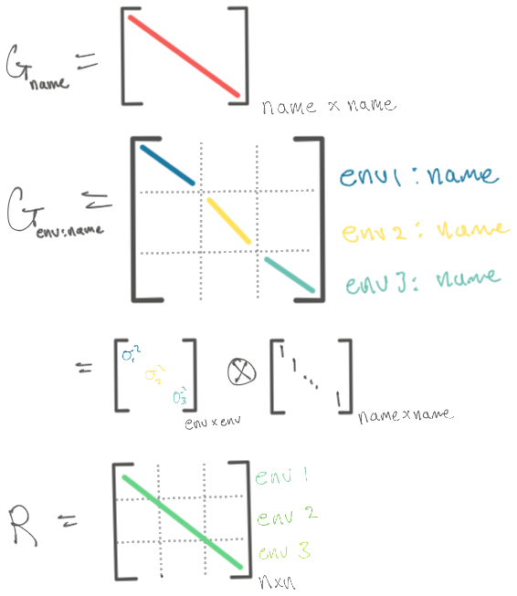

### lme4

You can force `lmer` to fit several random effects by expanding the variable to be a dummy variable

```r
DT_lmer <- bind_cols(DT_example,
                     model.matrix(~0 + Env, data=DT_example))
DT_lmer %>% names()
```

```
##  [1] "Name"       "Env"        "Loc"        "Year"       "Block"
##  [6] "Yield"      "Weight"     "EnvCA.2011" "EnvCA.2012" "EnvCA.2013"
```

```r
mmod2 <- lmer(Yield ~ Env + (1|Name) + (0 + EnvCA.2011 + EnvCA.2012 + EnvCA.2013 || Name),
              data = DT_lmer)

summary(mmod2)
```

```
## Linear mixed model fit by REML. t-tests use Satterthwaite's method [
## lmerModLmerTest]
## Formula:
## Yield ~ Env + (1 | Name) + (0 + EnvCA.2011 + EnvCA.2012 + EnvCA.2013 ||
##     Name)
##    Data: DT_lmer
##
## REML criterion at convergence: 932.2
##
## Scaled residuals:
##     Min      1Q  Median      3Q     Max
## -2.6628 -0.4984 -0.0448  0.4083  4.4902
##
## Random effects:
##  Groups   Name        Variance Std.Dev.
##  Name     (Intercept)  2.964   1.722
##  Name.1   EnvCA.2011  10.426   3.229
##  Name.2   EnvCA.2012   2.659   1.631
##  Name.3   EnvCA.2013   5.702   2.388
##  Residual              4.398   2.097
## Number of obs: 185, groups:  Name, 41
##
## Fixed effects:
##             Estimate Std. Error      df t value Pr(>|t|)
## (Intercept)  16.5109     0.8269 23.0600  19.966 4.73e-16 ***
## EnvCA.2012   -5.8089     0.8593 22.5089  -6.760 7.60e-07 ***
## EnvCA.2013   -6.4233     0.9359 30.3461  -6.863 1.21e-07 ***
## ---
## Signif. codes:  0 '***' 0.001 '**' 0.01 '*' 0.05 '.' 0.1 ' ' 1
##
## Correlation of Fixed Effects:
##            (Intr) ECA.2012
## EnvCA.2012 -0.860
## EnvCA.2013 -0.799  0.767
```

### sommer

```r
ans2r <- mmer(Yield~Env,
              random= ~Name + vsr(dsr(Env),Name), # the second one is an interaction term, and specifies
              rcov= ~units,
              data=DT_example, verbose = FALSE)

summary(ans2r)$varcomp
```

```
##                            VarComp VarCompSE   Zratio Constraint
## Name.Yield-Yield          2.964764  1.505450 1.969354   Positive
## CA.2011:Name.Yield-Yield 10.423874  4.454365 2.340148   Positive
## CA.2012:Name.Yield-Yield  2.657574  1.803218 1.473796   Positive
## CA.2013:Name.Yield-Yield  5.702131  2.511301 2.270588   Positive
## units.Yield-Yield         4.397686  0.651709 6.747930   Positive
```

```r
ans2e <- mmec(Yield~Env,
              random = ~Name + vsc(dsc(Env), isc(Name)),
              rcov = ~units,
              data = DT_example,
              verbose = FALSE)
summary(ans2e)$varcomp
```

```
##                            VarComp VarCompSE   Zratio Constraint
## Name:isc:isc              3.026478  1.525291 1.984198   Positive
## Env:Name:CA.2011:CA.2011 10.135905  3.763618 2.693128   Positive
## Env:Name:CA.2012:CA.2012  2.642893  2.210557 1.195578   Positive
## Env:Name:CA.2013:CA.2013  5.780788  3.144418 1.838429   Positive
## units:isc:isc             4.152878  1.520209 2.731780   Positive
```

### glmmTMB

```r
# glmmTMB
tmod2 <- glmmTMB(Yield ~ Env + (1|Name) + diag(Env+0|Name), # just for more intuitive summary results, (changes interpretation of covariance paramters)
                 data = DT_example,
                 REML = TRUE)
summary(tmod2)
```

```
##  Family: gaussian  ( identity )
## Formula:          Yield ~ Env + (1 | Name) + diag(Env + 0 | Name)
## Data: DT_example
##
##      AIC      BIC   logLik deviance df.resid
##    948.2    974.0   -466.1    932.2      180
##
## Random effects:
##
## Conditional model:
##  Groups   Name        Variance Std.Dev. Corr
##  Name     (Intercept)  2.964   1.722
##  Name.1   EnvCA.2011  10.426   3.229
##           EnvCA.2012   2.659   1.631    0.00
##           EnvCA.2013   5.702   2.388    0.00 0.00
##  Residual              4.398   2.097
## Number of obs: 185, groups:  Name, 41
##
## Dispersion estimate for gaussian family (sigma^2):  4.4
##
## Conditional model:
##             Estimate Std. Error z value Pr(>|z|)
## (Intercept)  16.5109     0.8281  19.939  < 2e-16 ***
## EnvCA.2012   -5.8089     0.8613  -6.744 1.54e-11 ***
## EnvCA.2013   -6.4233     0.9399  -6.834 8.24e-12 ***
## ---
## Signif. codes:  0 '***' 0.001 '**' 0.01 '*' 0.05 '.' 0.1 ' ' 1
```

### nlme

```r
# lme method of fitting heterogenous variance structure
lmod2 <- lme(Yield ~ Env,
             random = list(Name = pdBlocked(
               list(pdIdent(~1), # Identity for Name
                    pdDiag(~Env-1)))), # Diagonal structure for Environment:Name
             method = "REML",
             data = DT_example)

VarCorr(lmod2) # Nice, they match!
```

```
## Name = pdIdent(1), pdDiag(Env - 1)
##             Variance  StdDev
## (Intercept)  2.963725 1.721547
## EnvCA.2011  10.425967 3.228927
## EnvCA.2012   2.658958 1.630631
## EnvCA.2013   5.702071 2.387901
## Residual     4.397553 2.097034
```

```r
summary(lmod2)
```

```
## Linear mixed-effects model fit by REML
##   Data: DT_example
##        AIC      BIC    logLik
##   948.2295 973.8615 -466.1147
##
## Random effects:
##  Composite Structure: Blocked
##
##  Block 1: (Intercept)
##  Formula: ~1 | Name
##         (Intercept)
## StdDev:    1.721547
##
##  Block 2: EnvCA.2011, EnvCA.2012, EnvCA.2013
##  Formula: ~Env - 1 | Name
##  Structure: Diagonal
##         EnvCA.2011 EnvCA.2012 EnvCA.2013 Residual
## StdDev:   3.228927   1.630631   2.387901 2.097034
##
## Fixed effects:  Yield ~ Env
##                 Value Std.Error  DF   t-value p-value
## (Intercept) 16.510938 0.8269335 142 19.966464       0
## EnvCA.2012  -5.808897 0.8593216 142 -6.759864       0
## EnvCA.2013  -6.423279 0.9358819 142 -6.863343       0
##  Correlation:
##            (Intr) ECA.2012
## EnvCA.2012 -0.860
## EnvCA.2013 -0.799  0.767
##
## Standardized Within-Group Residuals:
##         Min          Q1         Med          Q3         Max
## -2.66278393 -0.49845117 -0.04478272  0.40832173  4.49017462
##
## Number of Observations: 185
## Number of Groups: 41
```

### afex

```r
set_default_contrasts()
```

```
## setting contr.treatment globally: options(contrasts=c('contr.treatment', 'contr.poly'))
```

```r
amod2 <- mixed(Yield ~ Env + (1|Name) + (0 + Env || Name),
      data = DT_example,
      check_contrasts = FALSE,
      expand_re = TRUE)
summary(amod2)
```

```
## Linear mixed model fit by REML. t-tests use Satterthwaite's method [
## lmerModLmerTest]
## Formula: Yield ~ Env + (1 | Name) + (0 + re2.EnvCA.2011 + re2.EnvCA.2012 +
##     re2.EnvCA.2013 || Name)
##    Data: data
##
## REML criterion at convergence: 932.2
##
## Scaled residuals:
##     Min      1Q  Median      3Q     Max
## -2.6628 -0.4984 -0.0448  0.4083  4.4902
##
## Random effects:
##  Groups   Name           Variance Std.Dev.
##  Name     (Intercept)     2.964   1.722
##  Name.1   re2.EnvCA.2011 10.426   3.229
##  Name.2   re2.EnvCA.2012  2.659   1.631
##  Name.3   re2.EnvCA.2013  5.702   2.388
##  Residual                 4.398   2.097
## Number of obs: 185, groups:  Name, 41
##
## Fixed effects:
##             Estimate Std. Error      df t value Pr(>|t|)
## (Intercept)  16.5109     0.8269 23.0600  19.966 4.73e-16 ***
## EnvCA.2012   -5.8089     0.8593 22.5089  -6.760 7.60e-07 ***
## EnvCA.2013   -6.4233     0.9359 30.3461  -6.863 1.21e-07 ***
## ---
## Signif. codes:  0 '***' 0.001 '**' 0.01 '*' 0.05 '.' 0.1 ' ' 1
##
## Correlation of Fixed Effects:
##            (Intr) ECA.2012
## EnvCA.2012 -0.860
## EnvCA.2013 -0.799  0.767
```

### SAS

```sas
# SAS
proc mixed data=dt;
class env name;
model yield = env;
random name / G;
random name*env / group = env;
run;
```

## Heterogenous G and R

Also called a Heterogeneous CS model.

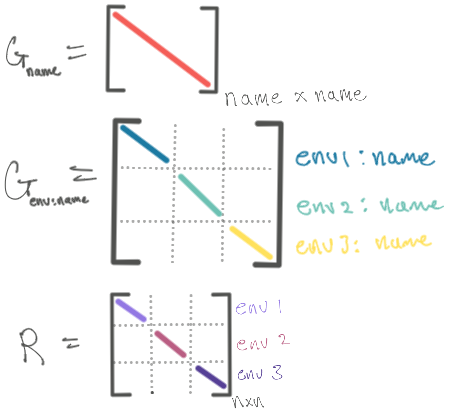

### sommer

```r
ans3r <- mmer(Yield~Env,
              random= ~Name + vsr(dsr(Env),Name), # the second one is an interaction term, and specifies
              rcov= ~vsr(dsr(Env),units),
              data=DT_example,
              verbose = FALSE)

sqrt(summary(ans3r)$varcomp$VarComp)
```

```
## [1] 1.721293 3.185337 1.370230 2.574714 2.223162 2.392690 1.599962
```

```r
summary(ans3r)$varcomp %>% mutate(sdComp = sqrt(VarComp),
                                  .after = VarComp)
```

```
##                             VarComp   sdComp VarCompSE   Zratio Constraint
## Name.Yield-Yield           2.962851 1.721293 1.4962000 1.980251   Positive
## CA.2011:Name.Yield-Yield  10.146369 3.185337 4.5073271 2.251083   Positive
## CA.2012:Name.Yield-Yield   1.877530 1.370230 1.8697568 1.004158   Positive
## CA.2013:Name.Yield-Yield   6.629152 2.574714 2.5028114 2.648682   Positive
## CA.2011:units.Yield-Yield  4.942450 2.223162 1.5245057 3.242001   Positive
## CA.2012:units.Yield-Yield  5.724963 2.392690 1.3123015 4.362536   Positive
## CA.2013:units.Yield-Yield  2.559880 1.599962 0.6399685 4.000010   Positive
```

```r
# Apparently order of your data matters, and can result in an error message of not fitting... can't find documentation as to why.
DT <- DT_example[with(DT_example, order(Env)), ]

ans3e <- mmec(Yield~Env,
              random = ~Name + vsc(dsc(Env), isc(Name)),
              rcov = ~vsc(dsc(Env), isc(units)),
              data = DT, # DT_example here will result in failure...
              verbose = FALSE)
summary(ans3e)$varcomp
```

```
##                             VarComp VarCompSE   Zratio Constraint
## Name:isc:isc               2.969457 1.3199316 2.249705   Positive
## Env:Name:CA.2011:CA.2011  10.113270 4.2317594 2.389850   Positive
## Env:Name:CA.2012:CA.2012   1.874589 1.3918727 1.346810   Positive
## Env:Name:CA.2013:CA.2013   6.625506 2.3850257 2.777960   Positive
## Env:units:CA.2011:CA.2011  4.953675 1.3389505 3.699670   Positive
## Env:units:CA.2012:CA.2012  5.725455 1.2010534 4.767027   Positive
## Env:units:CA.2013:CA.2013  2.561167 0.5872852 4.361029   Positive
```

### nlme

```r
# lme example with heterogenous G and R
lmod3 <- lme(Yield ~ Env,
             random = list(Name = pdBlocked(list(
               pdIdent(form = ~1), # Name
               pdDiag(form = ~Env-1)))), # Name:Env
             weights = varIdent(form = ~1 | Env),
             method = "REML",
             data = DT_example)

summary(lmod3)
```

```
## Linear mixed-effects model fit by REML
##   Data: DT_example
##        AIC      BIC    logLik
##   946.7659 978.8059 -463.3829
##
## Random effects:
##  Composite Structure: Blocked
##
##  Block 1: (Intercept)
##  Formula: ~1 | Name
##         (Intercept)
## StdDev:    1.721021
##
##  Block 2: EnvCA.2011, EnvCA.2012, EnvCA.2013
##  Formula: ~Env - 1 | Name
##  Structure: Diagonal
##         EnvCA.2011 EnvCA.2012 EnvCA.2013 Residual
## StdDev:   3.185572   1.370587   2.574817  2.39263
##
## Variance function:
##  Structure: Different standard deviations per stratum
##  Formula: ~1 | Env
##  Parameter estimates:
##   CA.2012   CA.2013   CA.2011
## 1.0000000 0.6686978 0.9291778
## Fixed effects:  Yield ~ Env
##                 Value Std.Error  DF   t-value p-value
## (Intercept) 16.507683 0.8268640 142 19.964204       0
## EnvCA.2012  -5.816899 0.8575800 142 -6.782923       0
## EnvCA.2013  -6.412440 0.9356534 142 -6.853436       0
##  Correlation:
##            (Intr) ECA.2012
## EnvCA.2012 -0.861
## EnvCA.2013 -0.799  0.768
##
## Standardized Within-Group Residuals:
##         Min          Q1         Med          Q3         Max
## -2.07307332 -0.53566469 -0.05597277  0.46043655  4.19617802
##
## Number of Observations: 185
## Number of Groups: 41
```

```r
VarCorr(lmod3)
```

```
## Name = pdIdent(1), pdDiag(Env - 1)
##             Variance  StdDev
## (Intercept)  2.961912 1.721021
## EnvCA.2011  10.147871 3.185572
## EnvCA.2012   1.878509 1.370587
## EnvCA.2013   6.629680 2.574817
## Residual     5.724679 2.392630
```

```r
sigma_hat <- summary(lmod3)$sigma # for some reason, defaults to CA.2012 for the "reference" sigma
sigma_weights <- coef(lmod3$modelStruct$varStruct, unconstrained=FALSE) # extract the weights estimated for each Env
c(CA.2012 = sigma_hat, sigma_hat*sigma_weights)^2 # Multiply reference sigma to weights for final sd estimates (square for variance)
```

```
##  CA.2012  CA.2013  CA.2011
## 5.724679 2.559829 4.942524
```

```r
intervals(lmod3) # for the approximate confidence intervals
```

```
## Approximate 95% confidence intervals
##
##  Fixed effects:
##                 lower      est.     upper
## (Intercept) 14.873129 16.507683 18.142237
## EnvCA.2012  -7.512173 -5.816899 -4.121626
## EnvCA.2013  -8.262050 -6.412440 -4.562831
##
##  Random Effects:
##   Level: Name
##                    lower     est.    upper
## sd(1)          1.0650575 1.721021 2.780988
## sd(EnvCA.2011) 2.0264211 3.185572 5.007780
## sd(EnvCA.2012) 0.4935377 1.370587 3.806212
## sd(EnvCA.2013) 1.7766278 2.574817 3.731609
##
##  Variance function:
##             lower      est.     upper
## CA.2013 0.4773923 0.6686978 0.9366651
## CA.2011 0.6366733 0.9291778 1.3560666
##
##  Within-group standard error:
##    lower     est.    upper
## 1.897397 2.392630 3.017122
```

```r
# picked A01143-3C because it is present in all 3 environments
getVarCov(lmod3, type = "random.effects") # G
```

```
## Random effects variance covariance matrix
##             (Intercept) EnvCA.2011 EnvCA.2012 EnvCA.2013
## (Intercept)      2.9619      0.000     0.0000     0.0000
## EnvCA.2011       0.0000     10.148     0.0000     0.0000
## EnvCA.2012       0.0000      0.000     1.8785     0.0000
## EnvCA.2013       0.0000      0.000     0.0000     6.6297
##   Standard Deviations: 1.721 3.1856 1.3706 2.5748
```

```r
getVarCov(lmod3, individuals = "A01143-3C", type = "conditional") # R
```

```
## Name A01143-3C
## Conditional variance covariance matrix
##        1      2      3      4      5      6
## 1 5.7247 0.0000 0.0000 0.0000 0.0000 0.0000
## 2 0.0000 5.7247 0.0000 0.0000 0.0000 0.0000
## 3 0.0000 0.0000 2.5598 0.0000 0.0000 0.0000
## 4 0.0000 0.0000 0.0000 4.9425 0.0000 0.0000
## 5 0.0000 0.0000 0.0000 0.0000 4.9425 0.0000
## 6 0.0000 0.0000 0.0000 0.0000 0.0000 2.5598
##   Standard Deviations: 2.3926 2.3926 1.5999 2.2232 2.2232 1.5999
```

```r
getVarCov(lmod3, individuals = "A01143-3C", type = "marginal") # ZGZ + R
```

```
## Name A01143-3C
## Marginal variance covariance matrix
##         1       2       3       4       5       6
## 1 10.5650  4.8404  2.9619  2.9619  2.9619  2.9619
## 2  4.8404 10.5650  2.9619  2.9619  2.9619  2.9619
## 3  2.9619  2.9619 12.1510  2.9619  2.9619  9.5916
## 4  2.9619  2.9619  2.9619 18.0520 13.1100  2.9619
## 5  2.9619  2.9619  2.9619 13.1100 18.0520  2.9619
## 6  2.9619  2.9619  9.5916  2.9619  2.9619 12.1510
##   Standard Deviations: 3.2504 3.2504 3.4859 4.2488 4.2488 3.4859
```

### glmmTMB

```r
# glmmTMB workaround for heterogenous R, need to code individual units as factor
DT_TMB_example <- DT_example %>% mutate(units = as.factor(1:n()))

# gives "false convergence warning": https://cran.r-project.org/web/packages/glmmTMB/vignettes/troubleshooting.html
# tough to diagnose
tmod3 <- glmmTMB(Yield ~ Env + (1|Name) + diag(Env + 0 | Name) + diag(Env + 0 | units),
                 dispformula = ~0,
                 REML = TRUE,
                 data = DT_TMB_example)

# update the optimizer method
tmod3_bfgs <- update(tmod3, control = glmmTMBControl(optimizer = optim,
                                                     optArgs = list(method="BFGS")))

# extract variance components
tmod3_bfgs %>% tidy(effects = "ran_pars") %>%
  filter(startsWith(term, "sd")) %>%
  separate(term, into = c("term", "partition"), sep = "__") %>%
  mutate(var_est = estimate^2) %>%
  dplyr::select(group, partition, var_est)
```

```
## # A tibble: 7 × 3
##   group  partition   var_est
##   <chr>  <chr>         <dbl>
## 1 Name   (Intercept)    2.96
## 2 Name.1 EnvCA.2011    10.1
## 3 Name.1 EnvCA.2012     1.88
## 4 Name.1 EnvCA.2013     6.63
## 5 units  EnvCA.2011     4.94
## 6 units  EnvCA.2012     5.72
## 7 units  EnvCA.2013     2.56
```

### SAS

```sas
proc mixed data=dt;
class env name;
model yield = env;
random name;
random name*env / group = env;
repeated / group = env;
run;
```

SAS output for above code

| Cov | Parm | Group | Estimate |
| --- | --- | --- | --- |
| name |  |  | 3.0647 |
| env*name | env | “CA.2011 | 10.0346 |
| env*name | env | “CA.2012 | 1.8875 |
| env*name | env | “CA.2013 | 6.5388 |
| Residual | env | “CA.2011 | 4.9424 |
| Residual | env | “CA.2012 | 5.7143 |
| Residual | env | “CA.2013 | 2.5599 |

## Unstructured G, Heterogenous R

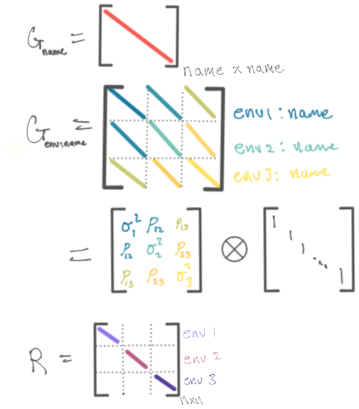

### sommer

```r
ans4r <- mmer(Yield~Env,
              random=~ vsr(usr(Env), Name), # we drop name from the model just for illustration (too many variables)
              rcov=~vsr(dsr(Env),units),
              data=DT_example, verbose = FALSE)

summary(ans4r)$varcomp
```

```
##                                     VarComp VarCompSE    Zratio Constraint
## CA.2011:Name.Yield-Yield         15.6650010 5.4206906 2.8898534   Positive
## CA.2012:CA.2011:Name.Yield-Yield  6.1101600 2.4850649 2.4587527   Unconstr
## CA.2012:Name.Yield-Yield          4.5296090 1.8208107 2.4876881   Positive
## CA.2013:CA.2011:Name.Yield-Yield  6.3844808 3.0658977 2.0824181   Unconstr
## CA.2013:CA.2012:Name.Yield-Yield  0.3929997 1.5233985 0.2579757   Unconstr
## CA.2013:Name.Yield-Yield          8.5972750 2.4837814 3.4613654   Positive
## CA.2011:units.Yield-Yield         4.9698460 1.5322540 3.2434870   Positive
## CA.2012:units.Yield-Yield         5.6729333 1.3007862 4.3611574   Positive
## CA.2013:units.Yield-Yield         2.5570940 0.6392821 3.9999462   Positive
```

```r
# Display the Variance components as a matrix
G_vec <- summary(ans4r)$varcomp %>% slice(1:6) %>% pull(VarComp)
G <- Matrix(0,
            nrow = 3,
            ncol = 3)
G[upper.tri(G, diag = TRUE)] <- G_vec
colnames(G) <- c("CA.2011", "CA.2012", "CA.2013")
rownames(G) <- c("CA.2011", "CA.2012", "CA.2013")
G
```

```
## 3 x 3 Matrix of class "dtrMatrix"
##            CA.2011    CA.2012    CA.2013
## CA.2011 15.6650010  6.1101600  6.3844808
## CA.2012          .  4.5296090  0.3929997
## CA.2013          .          .  8.5972750
```

### nlme

```r
# lme version. Note we dropped "Name" from the model here because otherwise the std error of the variance estimates were HUGE. checked with interval(lmod4)
lmod4 <- lme(Yield ~ Env,
             random = list(Name = pdSymm(form = ~Env-1)), # Name:Env
             weights = varIdent(form = ~1 | Env),
             method = "REML",
             data = DT_example)
getVarCov(lmod4) # G, now that we specify the same likelihood, the answers are the same
```

```
## Random effects variance covariance matrix
##            EnvCA.2011 EnvCA.2012 EnvCA.2013
## EnvCA.2011    15.6640    6.11080    6.38400
## EnvCA.2012     6.1108    4.53100    0.39141
## EnvCA.2013     6.3840    0.39141    8.59800
##   Standard Deviations: 3.9578 2.1286 2.9322
```

```r
getVarCov(lmod4, individual = "A01143-3C",type = "conditional") # R
```

```
## Name A01143-3C
## Conditional variance covariance matrix
##        1      2     3    4    5     6
## 1 5.6722 0.0000 0.000 0.00 0.00 0.000
## 2 0.0000 5.6722 0.000 0.00 0.00 0.000
## 3 0.0000 0.0000 2.557 0.00 0.00 0.000
## 4 0.0000 0.0000 0.000 4.97 0.00 0.000
## 5 0.0000 0.0000 0.000 0.00 4.97 0.000
## 6 0.0000 0.0000 0.000 0.00 0.00 2.557
##   Standard Deviations: 2.3816 2.3816 1.5991 2.2294 2.2294 1.5991
```

```r
# summary(lmod4)
```

```r
# manual way of extracting the weights and multiplying by sigma for the residual variance components.
# lmod4$modelStruct$varStruct # The variance structure of the residuals is in this object
vw <- 1 / varWeights(lmod4$modelStruct$varStruct) # accessor function gives weights, which is inverse of sigma multiplier
(vw[!duplicated(vw)] * lmod4$sigma)^2 # deduplicate, then multiply by sigma for variance
```

[output not shown]

### glmmTMB

```r
## glmmTMB
tmod4 <- glmmTMB(Yield ~ Env + us(Env + 0 | Name) + diag(Env + 0 | units), # drop name for estimability...
                 dispformula = ~0,
                 REML = TRUE,
                 data=DT_TMB_example)
summary(tmod4)
```

```
##  Family: gaussian  ( identity )
## Formula:          Yield ~ Env + us(Env + 0 | Name) + diag(Env + 0 | units)
## Dispersion:             ~0
## Data: DT_TMB_example
##
##      AIC      BIC   logLik deviance df.resid
##    942.9    981.5   -459.5    918.9      176
##
## Random effects:
##
## Conditional model:
##  Groups Name       Variance Std.Dev. Corr
##  Name   EnvCA.2011 15.665   3.958
##         EnvCA.2012  4.531   2.129    0.73
##         EnvCA.2013  8.598   2.932    0.55 0.06
##  units  EnvCA.2011  4.970   2.229
##         EnvCA.2012  5.672   2.382    0.00
##         EnvCA.2013  2.557   1.599    0.00 0.00
## Number of obs: 185, groups:  Name, 41; units, 185
##
## Conditional model:
##             Estimate Std. Error z value Pr(>|z|)
## (Intercept)  16.3313     0.8174  19.980  < 2e-16 ***
## EnvCA.2012   -5.6959     0.7444  -7.652 1.98e-14 ***
## EnvCA.2013   -6.2711     0.8282  -7.572 3.67e-14 ***
## ---
## Signif. codes:  0 '***' 0.001 '**' 0.01 '*' 0.05 '.' 0.1 ' ' 1
```

```r
# tmb_sd <- vcov(tmod4,full=TRUE) %>% diag() %>% `[`(4:12) %>% sqrt()
# tmb_logsd <- tmod$sdr$par.fixed[2:5]
# tmb_logsd <- tmb_logsd[c(1, 2, 3, 1, 2, 3, 4, 4, 4)]
# tmb_sd*2*exp(2*tmb_logsd)
#
# sqrt(2*exp(tmod4$sdr$par.fixed * 2))
# confint(tmod4, component = "all", parm = c(1, 2, 3, 4, 5))
# glmmTMB:::confint.glmmTMB(tmod4,parm="theta_")
```

## Multivariate, Homogenous variance models

### sommer

```r
ans5r <- mmer(cbind(Yield, Weight) ~ Env,
              random= ~ vsr(Name, Gtc=unsm(2)),
              rcov= ~ vsr(units, Gtc=diag(2)),
              data=DT_example, verbose = FALSE)
summary(ans5r)$varcomp
```

```
##                         VarComp  VarCompSE   Zratio Constraint
## u:Name.Yield-Yield    5.0023799 1.48723681 3.363540   Positive
## u:Name.Yield-Weight   1.4364292 0.33713194 4.260733   Unconstr
## u:Name.Weight-Weight  0.2813217 0.08054357 3.492789   Positive
## u:units.Yield-Yield   7.6133497 0.88506057 8.602066   Positive
## u:units.Weight-Weight 0.3586951 0.04189443 8.561882   Positive
```

# Additional Resources

Right now these resources are relatively unorganized, but contain a wealth of information. It seems like the variance modeling is scattered throughout the packages in R.

- [Factor Specific Variances](https://rpubs.com/bbolker/factorvar) - gives example of “G” side and “R” side for heterogeneous variance modeling. There is a correct way and incorrect way to specify this. Both are heterogeneous variance component style matrices.
- [Covariance Structures in R](https://rpubs.com/samuelkn/CovarianceStructuresInR) - messier overview of “G” and “R” side matrix structuring, however breaks down the examples quite well in terms of how to actually specify the model that we’d like.
- [Overview of Major Computer Package for Genomic Prediction of Complex Traits](https://link.springer.com/protocol/10.1007/978-1-0716-2205-6_6) - author of the sommer package, excellet overview of the ecosystem and a worked example of reml estimation with variance structures.
- [MMFAIR Heterogenous Error Variance](https://schmidtpaul.github.io/MMFAIR/heterogeneous_error_variance.html) - a nice rmarkdown description of a lot of different error structures, with code in sommer, nlme, lme4, SAS

For more of a philosophical take on confirmatory analyses:

- [Random effects structure for confirmatory hypothesis testing: Keep it maximal](https://www-sciencedirect-com.ezproxy.library.wisc.edu/science/article/pii/S0749596X12001180?via%3Dihub#b0210) - argues that for confirmatory analyses, should use the most random effects possible that make sense for the design.